# Predicting Home Prices

Siddhartha Jetti

December 27, 2016

# 1. Problem Defnition

Predict House prices in Suburbs of Boston. The Dataset Description can be found at : https://archive.ics.uci.edu/ml/datasets/Housing

1. Load libraries

```r
library(mlbench)
library(caret)
```

```r
library(corrplot)
```

2. Load dataset

```r
data(BostonHousing)
```

3. Split-out validation dataset create a list of 80% of the rows in the original dataset for training the model. select 20% of the data for validation use the remaining 80% of data to training and testing the models

```r
set.seed(7)
validation_index <- createDataPartition(BostonHousing$medv, p=0.80, list=FALSE)
validation <- BostonHousing[-validation_index,]
dataset <- BostonHousing[validation_index,]
```

# 2. Summarize Data

Dimensions of dataset

```r
dim(dataset)
```

```
## [1] 407  14
```

List types for each attribute

```r
sapply(dataset, class)
```

```
##      crim        zn     indus      chas       nox        rm       age
## "numeric" "numeric" "numeric"  "factor" "numeric" "numeric" "numeric"
##       dis       rad       tax   ptratio         b     lstat      medv
## "numeric" "numeric" "numeric" "numeric" "numeric" "numeric" "numeric"
```

```r
head(dataset, n=20)
```

```
##       crim   zn indus chas   nox    rm   age    dis rad tax ptratio      b
## 2  0.02731  0.0  7.07    0 0.469 6.421  78.9 4.9671   2 242    17.8 396.90
## 3  0.02729  0.0  7.07    0 0.469 7.185  61.1 4.9671   2 242    17.8 392.83
## 4  0.03237  0.0  2.18    0 0.458 6.998  45.8 6.0622   3 222    18.7 394.63
## 5  0.06905  0.0  2.18    0 0.458 7.147  54.2 6.0622   3 222    18.7 396.90
## 6  0.02985  0.0  2.18    0 0.458 6.430  58.7 6.0622   3 222    18.7 394.12
## 7  0.08829 12.5  7.87    0 0.524 6.012  66.6 5.5605   5 311    15.2 395.60
## 8  0.14455 12.5  7.87    0 0.524 6.172  96.1 5.9505   5 311    15.2 396.90
## 9  0.21124 12.5  7.87    0 0.524 5.631 100.0 6.0821   5 311    15.2 386.63
## 13 0.09378 12.5  7.87    0 0.524 5.889  39.0 5.4509   5 311    15.2 390.50
## 14 0.62976  0.0  8.14    0 0.538 5.949  61.8 4.7075   4 307    21.0 396.90
## 15 0.63796  0.0  8.14    0 0.538 6.096  84.5 4.4619   4 307    21.0 380.02
## 16 0.62739  0.0  8.14    0 0.538 5.834  56.5 4.4986   4 307    21.0 395.62
## 17 1.05393  0.0  8.14    0 0.538 5.935  29.3 4.4986   4 307    21.0 386.85
## 18 0.78420  0.0  8.14    0 0.538 5.990  81.7 4.2579   4 307    21.0 386.75
```

[output cut: 27 more lines]

summarize attribute distributions

```r
summary(dataset)
```

```
##       crim                zn            indus       chas
##  Min.   : 0.00906   Min.   : 0.00   Min.   : 0.46   0:376
##  1st Qu.: 0.08556   1st Qu.: 0.00   1st Qu.: 5.19   1: 31
##  Median : 0.28955   Median : 0.00   Median : 9.90
##  Mean   : 3.58281   Mean   :10.57   Mean   :11.36
##  3rd Qu.: 3.50464   3rd Qu.: 0.00   3rd Qu.:18.10
##  Max.   :88.97620   Max.   :95.00   Max.   :27.74
##       nox               rm             age              dis
##  Min.   :0.3850   Min.   :3.863   Min.   :  2.90   Min.   : 1.130
##  1st Qu.:0.4530   1st Qu.:5.873   1st Qu.: 45.05   1st Qu.: 2.031
##  Median :0.5380   Median :6.185   Median : 77.70   Median : 3.216
##  Mean   :0.5577   Mean   :6.279   Mean   : 68.83   Mean   : 3.731
##  3rd Qu.:0.6310   3rd Qu.:6.611   3rd Qu.: 94.55   3rd Qu.: 5.100
##  Max.   :0.8710   Max.   :8.780   Max.   :100.00   Max.   :10.710
##       rad              tax           ptratio            b
##  Min.   : 1.000   Min.   :188.0   Min.   :12.60   Min.   :  0.32
##  1st Qu.: 4.000   1st Qu.:279.0   1st Qu.:17.40   1st Qu.:374.50
##  Median : 5.000   Median :330.0   Median :19.00   Median :391.13
##  Mean   : 9.464   Mean   :405.6   Mean   :18.49   Mean   :357.88
##  3rd Qu.:24.000   3rd Qu.:666.0   3rd Qu.:20.20   3rd Qu.:396.27
##  Max.   :24.000   Max.   :711.0   Max.   :22.00   Max.   :396.90
##      lstat             medv
##  Min.   : 1.730   Min.   : 5.00
##  1st Qu.: 6.895   1st Qu.:17.05
##  Median :11.500   Median :21.20
##  Mean   :12.827   Mean   :22.61
##  3rd Qu.:17.175   3rd Qu.:25.00
##  Max.   :37.970   Max.   :50.00
```

convert factor to numeric

```r
dataset[,4] <- as.numeric(as.character(dataset[,4]))
```

1. Descriptive statistics

```r
cor(dataset[,1:13])
```

```
##                crim          zn       indus        chas        nox
## crim     1.00000000 -0.19790631  0.40597009 -0.05713065  0.4232413
## zn      -0.19790631  1.00000000 -0.51895069 -0.04843477 -0.5058512
## indus    0.40597009 -0.51895069  1.00000000  0.08003629  0.7665481
## chas    -0.05713065 -0.04843477  0.08003629  1.00000000  0.1027366
## nox      0.42324132 -0.50585121  0.76654811  0.10273656  1.0000000
## rm      -0.21513269  0.28942883 -0.37673408  0.08252441 -0.2988506
## age      0.35438190 -0.57070265  0.65858310  0.10938121  0.7238371
## dis     -0.39050970  0.65618742 -0.72305885 -0.11142420 -0.7708680
## rad      0.64240501 -0.29952976  0.56774365 -0.00901245  0.5851676
## tax      0.60622608 -0.28791668  0.68070916 -0.02779018  0.6521787
## ptratio  0.28929828 -0.35341215  0.32920610 -0.13554380  0.1416616
## b       -0.30211854  0.16927489 -0.33597951  0.04724420 -0.3620791
## lstat    0.47537617 -0.39712686  0.59212718 -0.04569239  0.5819645
##                  rm        age        dis         rad         tax
## crim    -0.21513269  0.3543819 -0.3905097  0.64240501  0.60622608
## zn       0.28942883 -0.5707027  0.6561874 -0.29952976 -0.28791668
## indus   -0.37673408  0.6585831 -0.7230588  0.56774365  0.68070916
## chas     0.08252441  0.1093812 -0.1114242 -0.00901245 -0.02779018
## nox     -0.29885055  0.7238371 -0.7708680  0.58516760  0.65217875
## rm       1.00000000 -0.2325359  0.1952159 -0.19149122 -0.26794733
## age     -0.23253586  1.0000000 -0.7503321  0.45235421  0.50164657
## dis      0.19521590 -0.7503321  1.0000000 -0.49382744 -0.52649325
## rad     -0.19149122  0.4523542 -0.4938274  1.00000000  0.92137876
## tax     -0.26794733  0.5016466 -0.5264932  0.92137876  1.00000000
## ptratio -0.32000372  0.2564318 -0.2021897  0.45312318  0.44192428
## b        0.15539923 -0.2512574  0.2826819 -0.41033069 -0.41848779
## lstat   -0.62038075  0.5932128 -0.4957302  0.47306604  0.52339243
##            ptratio          b       lstat
## crim     0.2892983 -0.3021185  0.47537617
## zn      -0.3534121  0.1692749 -0.39712686
## indus    0.3292061 -0.3359795  0.59212718
## chas    -0.1355438  0.0472442 -0.04569239
## nox      0.1416616 -0.3620791  0.58196447
## rm      -0.3200037  0.1553992 -0.62038075
## age      0.2564318 -0.2512574  0.59321281
## dis     -0.2021897  0.2826819 -0.49573024
## rad      0.4531232 -0.4103307  0.47306604
## tax      0.4419243 -0.4184878  0.52339243
## ptratio  1.0000000 -0.1495283  0.35375936
## b       -0.1495283  1.0000000 -0.37661571
## lstat    0.3537594 -0.3766157  1.00000000
```

2. Data visualizations histograms for each attribute

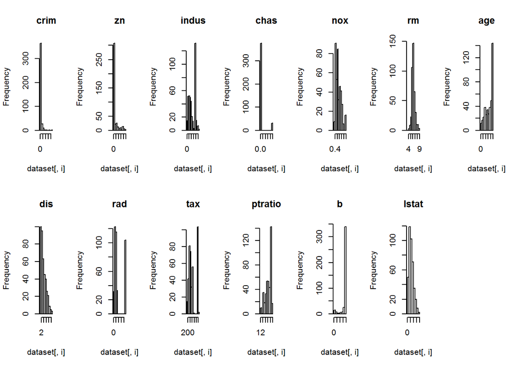

```r
par(mfrow=c(2,7))
for(i in 1:13) {
    hist(dataset[,i], main=names(dataset)[i])
}
```

density plot for each attribute

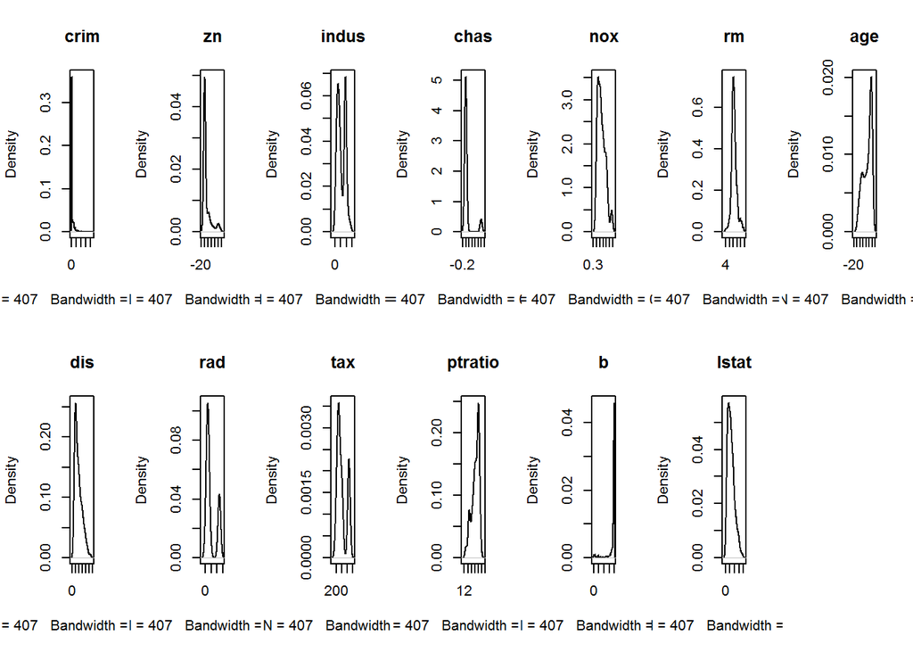

```r
par(mfrow=c(2,7))
for(i in 1:13) {
    plot(density(dataset[,i]), main=names(dataset)[i])
}
```

boxplots for each attribute

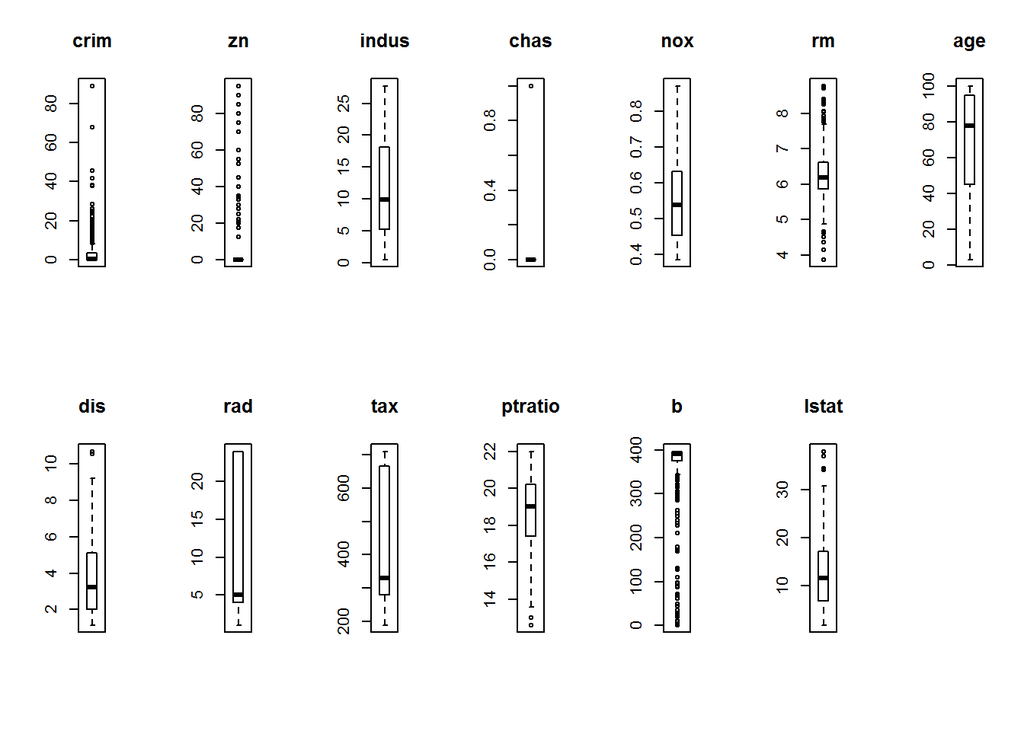

```r
par(mfrow=c(2,7))
for(i in 1:13) {
    boxplot(dataset[,i], main=names(dataset)[i])
}
```

Multivariate Visualizations scatterplot matrix

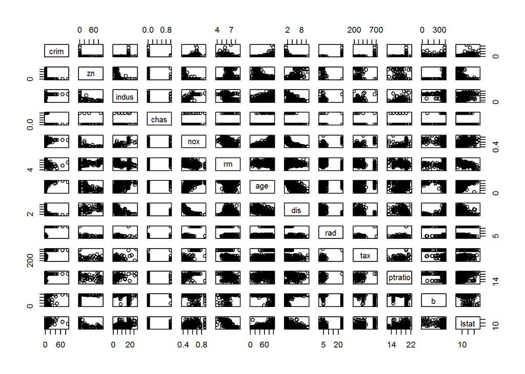

```r
pairs(dataset[,1:13])
```

correlation plot

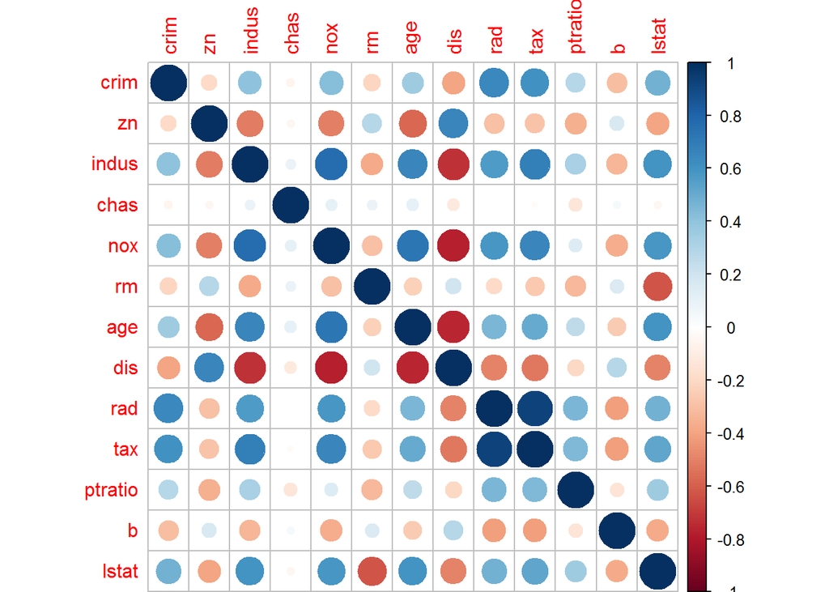

```r
correlations <- cor(dataset[,1:13])
corrplot(correlations, method="circle")
```

# 3. Evaluate Algorithms a.Run algorithms using 10-fold cross validation

```r
control <- trainControl(method="repeatedcv", number=10, repeats=3)
metric <- "RMSE"
```

Fit Linear model

```r
set.seed(7)
fit.lm <- train(medv~., data=dataset, method="lm", metric=metric, preProc=c("center", "scale"), trControl=control)
```

Fit Generalized Linear Model

```r
set.seed(7)
fit.glm <- train(medv~., data=dataset, method="glm", metric=metric, preProc=c("center", "scale"), trControl=control)
```

Fit GLMNET

```r
set.seed(7)
fit.glmnet <- train(medv~., data=dataset, method="glmnet", metric=metric, preProc=c("center", "scale"), trControl=control)
```

Fit SVM

```r
set.seed(7)
fit.svm <- train(medv~., data=dataset, method="svmRadial", metric=metric, preProc=c("center", "scale"), trControl=control)
```

Fit CART

```r
set.seed(7)
grid <- expand.grid(.cp=c(0, 0.05, 0.1))
fit.cart <- train(medv~., data=dataset, method="rpart", metric=metric, tuneGrid=grid, preProc=c("center", "scale"), trControl=control)
```

Fit kNN

```r
set.seed(7)
fit.knn <- train(medv~., data=dataset, method="knn", metric=metric, preProc=c("center", "scale"), trControl=control)
```

Finally Compare algorithms

```r
results <- resamples(list(LM=fit.lm, GLM=fit.glm, GLMNET=fit.glmnet, SVM=fit.svm, CART=fit.cart, KNN=fit.knn))
summary(results)
```

```
##
## Call:
## summary.resamples(object = results)
##
## Models: LM, GLM, GLMNET, SVM, CART, KNN
## Number of resamples: 30
##
## RMSE
##         Min. 1st Qu. Median  Mean 3rd Qu.  Max. NA's
## LM     3.514   4.056  4.773 4.963   5.529 9.448    0
## GLM    3.514   4.056  4.773 4.963   5.529 9.448    0
## GLMNET 3.484   4.017  4.767 4.955   5.520 9.506    0
## SVM    2.377   3.010  3.750 3.952   4.463 8.177    0
## CART   2.797   3.434  4.272 4.541   5.437 9.248    0
## KNN    2.394   3.509  4.471 4.555   5.089 8.757    0
##
## Rsquared
##          Min. 1st Qu. Median   Mean 3rd Qu.   Max. NA's
## LM     0.3169  0.6682 0.7428 0.7293  0.7984 0.8882    0
## GLM    0.3169  0.6682 0.7428 0.7293  0.7984 0.8882    0
## GLMNET 0.3092  0.6670 0.7437 0.7296  0.7989 0.8921    0
## SVM    0.5229  0.7803 0.8513 0.8290  0.8820 0.9418    0
## CART   0.3614  0.6733 0.8197 0.7680  0.8613 0.9026    0
## KNN    0.4313  0.7168 0.8024 0.7732  0.8588 0.9146    0
```

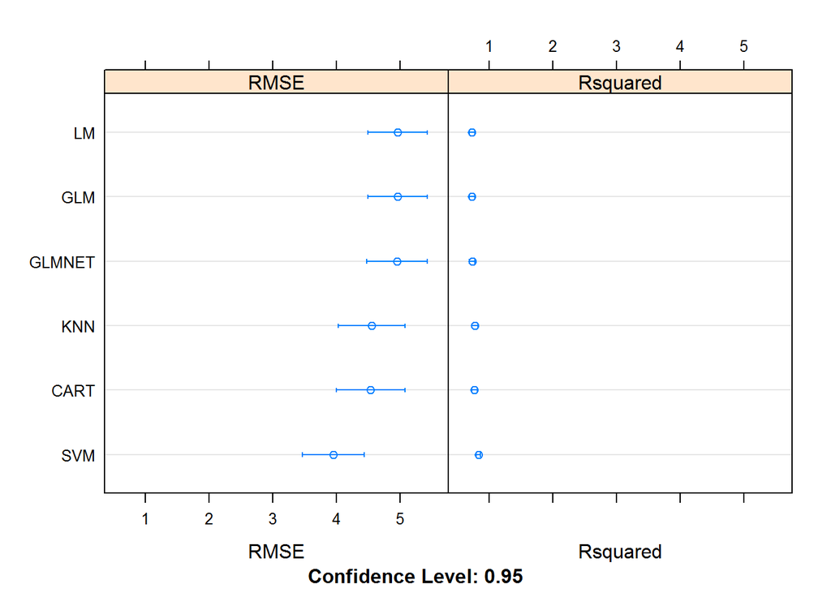

```r
dotplot(results)
```

b.Feature Selection

```r
set.seed(7)
cutoff <- 0.70
correlations <- cor(dataset[,1:13])
highlyCorrelated <- findCorrelation(correlations, cutoff=cutoff)
for (value in highlyCorrelated) {
    print(names(dataset)[value])
}
```

```
## [1] "indus"
## [1] "nox"
## [1] "tax"
## [1] "dis"
```

create a new dataset without highly corrected features.

```r
dataset_features <- dataset[,-highlyCorrelated]
dim(dataset_features)
```

```
## [1] 407  10
```

Run algorithms using 10-fold cross validation on dataset after removing correlated predictors.

```r
control <- trainControl(method="repeatedcv", number=10, repeats=3)
metric <- "RMSE"
```

Fit lm

```r
set.seed(7)
fit.lm <- train(medv~., data=dataset_features, method="lm", metric=metric, preProc=c("center", "scale"), trControl=control)
```

Fit GLM

```r
set.seed(7)
fit.glm <- train(medv~., data=dataset_features, method="glm", metric=metric, preProc=c("center", "scale"), trControl=control)
```

Fit GLMNET

```r
set.seed(7)
fit.glmnet <- train(medv~., data=dataset_features, method="glmnet", metric=metric, preProc=c("center", "scale"), trControl=control)
```

Fit SVM

```r
set.seed(7)
fit.svm <- train(medv~., data=dataset_features, method="svmRadial", metric=metric, preProc=c("center", "scale"), trControl=control)
```

Fit CART

```r
set.seed(7)
grid <- expand.grid(.cp=c(0, 0.05, 0.1))
fit.cart <- train(medv~., data=dataset_features, method="rpart", metric=metric, tuneGrid=grid, preProc=c("center", "scale"), trControl=control)
```

Fit kNN

```r
set.seed(7)
fit.knn <- train(medv~., data=dataset_features, method="knn", metric=metric, preProc=c("center", "scale"), trControl=control)
```

Compare algorithms

```r
feature_results <- resamples(list(LM=fit.lm, GLM=fit.glm, GLMNET=fit.glmnet, SVM=fit.svm, CART=fit.cart, KNN=fit.knn))
summary(feature_results)
```

```
##
## Call:
## summary.resamples(object = feature_results)
##
## Models: LM, GLM, GLMNET, SVM, CART, KNN
## Number of resamples: 30
##
## RMSE
##         Min. 1st Qu. Median  Mean 3rd Qu.  Max. NA's
## LM     3.431   4.439  4.908 5.277   5.998 9.982    0
## GLM    3.431   4.439  4.908 5.277   5.998 9.982    0
## GLMNET 3.283   4.330  4.950 5.236   5.895 9.869    0
## SVM    2.726   3.337  4.100 4.352   5.036 8.503    0
## CART   2.661   3.550  4.462 4.618   5.246 9.558    0
## KNN    2.488   3.377  4.467 4.453   5.051 8.889    0
##
## Rsquared
##          Min. 1st Qu. Median   Mean 3rd Qu.   Max. NA's
## LM     0.2505  0.6271 0.7125 0.6955  0.7797 0.8877    0
## GLM    0.2505  0.6271 0.7125 0.6955  0.7797 0.8877    0
## GLMNET 0.2581  0.6274 0.7174 0.7027  0.7783 0.8905    0
## SVM    0.4866  0.7522 0.8185 0.7883  0.8673 0.9168    0
## CART   0.3310  0.7067 0.7987 0.7607  0.8363 0.9360    0
## KNN    0.4105  0.7147 0.7981 0.7759  0.8648 0.9117    0
```

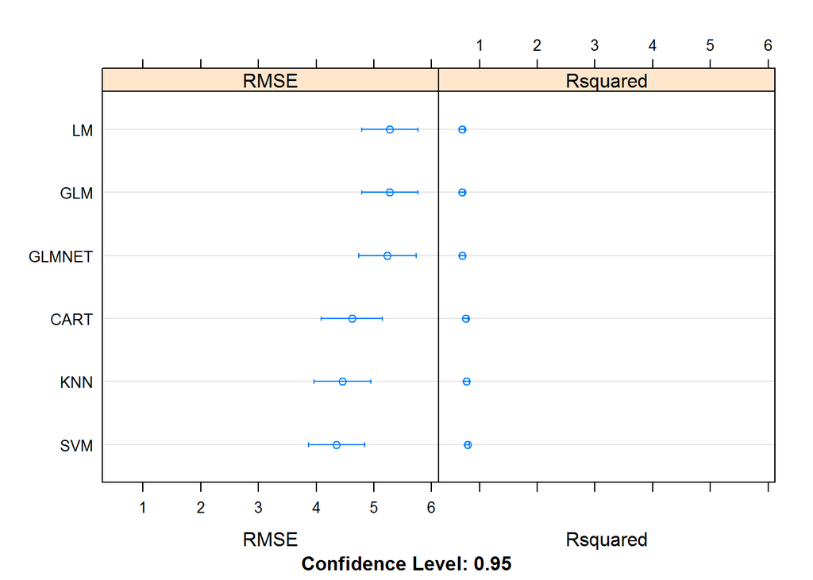

```r
dotplot(feature_results)
```

3. Apply tranformations and refit models.

Run algorithms using 10-fold cross validation on dataset after removing correlated predictors.

```r
control <- trainControl(method="repeatedcv", number=10, repeats=3)
metric <- "RMSE"
```

Fit lm

```r
set.seed(7)
fit.lm <- train(medv~., data=dataset_features, method="lm", metric=metric, preProc=c("center", "scale","BoxCox"), trControl=control)
```

Fit GLM

```r
set.seed(7)
fit.glm <- train(medv~., data=dataset_features, method="glm", metric=metric, preProc=c("center", "scale","BoxCox"), trControl=control)
```

Fit GLMNET

```r
set.seed(7)
fit.glmnet <- train(medv~., data=dataset_features, method="glmnet", metric=metric, preProc=c("center", "scale","BoxCox"), trControl=control)
```

Fit SVM

```r
set.seed(7)
fit.svm <- train(medv~., data=dataset_features, method="svmRadial", metric=metric, preProc=c("center", "scale","BoxCox"), trControl=control)
```

Fit CART

```r
set.seed(7)
grid <- expand.grid(.cp=c(0, 0.05, 0.1))
fit.cart <- train(medv~., data=dataset_features, method="rpart", metric=metric, tuneGrid=grid, preProc=c("center", "scale","BoxCox"), trControl=control)
```

Fit kNN

```r
set.seed(7)
fit.knn <- train(medv~., data=dataset_features, method="knn", metric=metric, preProc=c("center", "scale","BoxCox"), trControl=control)
```

Compare algorithms

```r
feature_results <- resamples(list(LM=fit.lm, GLM=fit.glm, GLMNET=fit.glmnet, SVM=fit.svm, CART=fit.cart, KNN=fit.knn))
summary(feature_results)
```

```
##
## Call:
## summary.resamples(object = feature_results)
##
## Models: LM, GLM, GLMNET, SVM, CART, KNN
## Number of resamples: 30
##
## RMSE
##         Min. 1st Qu. Median  Mean 3rd Qu.  Max. NA's
## LM     3.460   4.267  4.727 4.937   5.394 8.382    0
## GLM    3.460   4.267  4.727 4.937   5.394 8.382    0
## GLMNET 3.390   4.202  4.712 4.926   5.546 8.547    0
## SVM    2.489   3.123  3.837 4.030   4.744 8.059    0
## CART   2.661   3.550  4.462 4.619   5.246 9.558    0
## KNN    2.916   3.772  4.419 4.543   5.054 8.914    0
##
## Rsquared
##          Min. 1st Qu. Median   Mean 3rd Qu.   Max. NA's
## LM     0.4635  0.6817 0.7524 0.7283  0.7884 0.8963    0
## GLM    0.4635  0.6817 0.7524 0.7283  0.7884 0.8963    0
## GLMNET 0.4433  0.6773 0.7546 0.7298  0.7882 0.8959    0
## SVM    0.5394  0.7834 0.8424 0.8205  0.8828 0.9366    0
## CART   0.3310  0.7072 0.7987 0.7607  0.8363 0.9360    0
## KNN    0.4040  0.7158 0.8076 0.7724  0.8531 0.9047    0
```

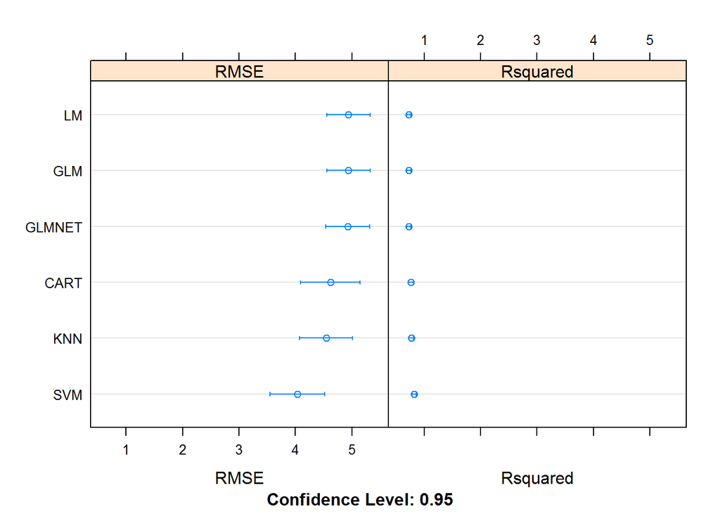

```r
dotplot(feature_results)
```

# 4. Improve Accuracy

1. Algorithm Tuning

Look at parameters

```r
print(fit.svm)
```

```
## Support Vector Machines with Radial Basis Function Kernel
##
## 407 samples
##   9 predictor
##
## Pre-processing: centered (9), scaled (9), Box-Cox transformation (7)
## Resampling: Cross-Validated (10 fold, repeated 3 times)
## Summary of sample sizes: 366, 367, 366, 366, 367, 367, ...
## Resampling results across tuning parameters:
##
##   C     RMSE      Rsquared
##   0.25  4.688959  0.7784489
##   0.50  4.284445  0.8036791
##   1.00  4.029789  0.8204519
##
## Tuning parameter 'sigma' was held constant at a value of 0.1304129
## RMSE was used to select the optimal model using  the smallest value.
## The final values used for the model were sigma = 0.1304129 and C = 1.
```

Tune SVM sigma and C parameters

```r
control <- trainControl(method="repeatedcv", number=10, repeats=3)
metric <- "RMSE"
set.seed(7)
grid <- expand.grid(.sigma=c(0.025, 0.05, 0.1, 0.15), .C=seq(1, 10, by=1))
fit.svm <- train(medv~., data=dataset, method="svmRadial", metric=metric, tuneGrid=grid, preProc=c("BoxCox"), trControl=control)
print(fit.svm)
```

```
## Support Vector Machines with Radial Basis Function Kernel
##
## 407 samples
##  13 predictor
##
## Pre-processing: Box-Cox transformation (11)
## Resampling: Cross-Validated (10 fold, repeated 3 times)
## Summary of sample sizes: 366, 367, 366, 366, 367, 367, ...
## Resampling results across tuning parameters:
##
##   sigma  C   RMSE      Rsquared
##   0.025   1  3.889703  0.8335201
##   0.025   2  3.685009  0.8470869
##   0.025   3  3.562851  0.8553298
##   0.025   4  3.453041  0.8628558
##   0.025   5  3.372501  0.8686287
##   0.025   6  3.306693  0.8731149
##   0.025   7  3.261471  0.8761873
##   0.025   8  3.232191  0.8780827
##   0.025   9  3.208426  0.8797434
##   0.025  10  3.186740  0.8812147
##   0.050   1  3.771428  0.8438368
##   0.050   2  3.484116  0.8634056
##   0.050   3  3.282230  0.8768963
##   0.050   4  3.179856  0.8829293
##   0.050   5  3.105290  0.8873315
##   0.050   6  3.054516  0.8907211
##   0.050   7  3.024010  0.8925927
##   0.050   8  3.003371  0.8936101
##   0.050   9  2.984457  0.8944677
##   0.050  10  2.977085  0.8948000
##   0.100   1  3.762027  0.8453751
##   0.100   2  3.300432  0.8747723
##   0.100   3  3.142907  0.8825268
##   0.100   4  3.071231  0.8862783
##   0.100   5  3.028898  0.8890841
##   0.100   6  3.015042  0.8900253
##   0.100   7  3.009815  0.8904964
##   0.100   8  3.005077  0.8909034
##   0.100   9  3.006147  0.8908668
##   0.100  10  3.006943  0.8908635
##   0.150   1  3.835849  0.8408209
##   0.150   2  3.318208  0.8716379
##   0.150   3  3.171005  0.8793969
##   0.150   4  3.151071  0.8809872
##   0.150   5  3.149461  0.8811425
##   0.150   6  3.154374  0.8807765
##   0.150   7  3.156741  0.8806358
##   0.150   8  3.157200  0.8806536
##   0.150   9  3.156256  0.8807690
##   0.150  10  3.156134  0.8807506
##
## RMSE was used to select the optimal model using  the smallest value.
## The final values used for the model were sigma = 0.05 and C = 10.
```

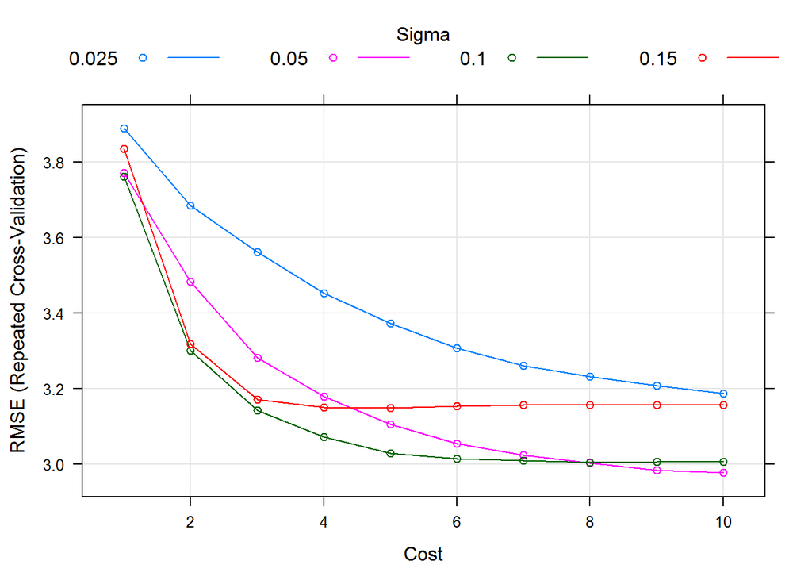

```r
plot(fit.svm)
```

2. Ensemble methods

train emsemble models

```r
control <- trainControl(method="repeatedcv", number=10, repeats=3)
metric <- "RMSE"
```

Fit Random Forest

```r
set.seed(7)
fit.rf <- train(medv~., data=dataset, method="rf", metric=metric, preProc=c("BoxCox"), trControl=control)
```

Fit Stochastic Gradient Boosting model

```r
set.seed(7)
fit.gbm <- train(medv~., data=dataset, method="gbm", metric=metric, preProc=c("BoxCox"), trControl=control, verbose=FALSE)
```

Fit Cubist

```r
set.seed(7)
fit.cubist <- train(medv~., data=dataset, method="cubist", metric=metric, preProc=c("BoxCox"), trControl=control)
```

Compare algorithms

```r
ensemble_results <- resamples(list(RF=fit.rf, GBM=fit.gbm, CUBIST=fit.cubist))
summary(ensemble_results)
```

```
##
## Call:
## summary.resamples(object = ensemble_results)
##
## Models: RF, GBM, CUBIST
## Number of resamples: 30
##
## RMSE
##         Min. 1st Qu. Median  Mean 3rd Qu.  Max. NA's
## RF     2.034   2.416  2.868 3.194   3.637 7.439    0
## GBM    2.194   2.631  2.861 3.283   3.724 7.457    0
## CUBIST 1.671   2.325  2.598 2.935   2.862 7.894    0
##
## Rsquared
##          Min. 1st Qu. Median   Mean 3rd Qu.   Max. NA's
## RF     0.5905  0.8702 0.9176 0.8827  0.9349 0.9565    0
## GBM    0.5934  0.8491 0.9088 0.8720  0.9301 0.9561    0
## CUBIST 0.5312  0.9051 0.9272 0.8945  0.9401 0.9700    0
```